# SEM Project 2 Self Evaluation

Caroline Lee

2024-02-24

### **Revisions for the self evaluation are in orange text.**

## Part I

Suppose a researcher was interested in investigating the determinants of coping styles for college students. To evaluate this researcher’s path model, Let’s assume six variables were collected from 200 college students as follows:

- v1: stress
- v2: efficacy
- v3: resilience
- v4: problem-solving coping
- v5: social-support coping
- v6: avoidance coping

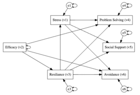

The file `coping.csv` contains the data for these six variables. The following path diagram presents the theory of the hypothetical:

1. **Let’s do initial model evaluations**.
   - (1-a) **How many endogenous variables in this model?**
     - There are 5 endogenous variables in this model: stress (v1), resilience (v3), problem solving (v4), social support (v5), and avoidance (v6).
   - (1-b) **How many parameters does this model have? Count each kind of parameters. Be sure to include the variance(s) of exogenous variable(s) and covariance(s) between exogenous variable(s), if any.**
     - Number of model parameters = 16
       - 10 regression paths
       - 5 residual variances
       - 1 variance for exogenous variable v2
   - (1-c) **What is the number of unique elements of the data covariance matrix?**
     - Number of unique elements in the data covariance matrix = $\frac{q(q+1)}{2} = \frac{6(6+1)}{2} = 21$
   - (1-d) **What is the degrees of freedom (*df*) for this model? Show how you derived the *df*.**
     - *df* = 21 - 16 = 5
   - (1-e) **List all possible indirect (mediation) effects of efficacy (v2) on avoidance coping (v6) in this model. Use a format of A→B→C, where the effect of variable A to variable C is mediated by variable B.**
     - Efficacy (v2) $\rightarrow$ Resilience (v3) $\rightarrow$ Avoidance (v6) such that the effect of v2 on v6 is mediated by v3.
     - **Efficacy (v2) $\rightarrow$ Resilience (v3) $\rightarrow$ Stress (v1) $\rightarrow$ Avoidance (v6)**
2. **Estimate this model using the bootstrap method with 10000 bootstrap iterations with Mplus via** `MplusAutomation`. **Request the indirect effects of efficacy** `v2` **on avoidance coping** `v6`. **Also, request standardized results, as well as bootstrap confidence intervals.**
   - (2-a) **Present the R code for (a) setting up the model by a combination of** `sink()` **and** `cat()` **functions, (b) running the model by the** `runModels()` **function, and (c) reading the output file by the** `readModels()` **function and save as an object called** `model01.fit`.
- Note: * By default, it appears that Mplus will include error covariances between endogenous variables with no direct path in-between. Therefore, you need to constrain these error terms to be 0. Specifically, you need to constrain that the error covariances between `v4` and `v5`, between `v4` and `v6`, and between `v5` and `v6` to be 0. - For example, to constrain the error covariance between `v4` and `v5` to 0, add a Mplus syntax line: `v4 with v5@0;`

**Revised code:**

```r
sink("project2q1.inp")
cat('
data:     file = coping.dat;

variable: names = stress efficacy resilien probsolv socisupp avoidanc;
          missing = .;

analysis: estimator = ml;
          bootstrap = 10000;

model:    probsolv on stress efficacy resilien;
          socisupp on stress resilien;
          avoidanc on stress efficacy resilien;
          resilien on efficacy;
          stress on resilien;
          probsolv with socisupp@0;
          probsolv with avoidanc@0;
          socisupp with avoidanc@0;

model indirect:
          avoidanc ind efficacy;

output: STDYX cinterval(bootstrap);
')
sink()
```

```r
runModels("project2q1.inp")
```

```r
model01.fit <- readModels("project2q1.out")
```

**New output:**

```
Mplus VERSION 8.6
MUTHEN & MUTHEN
02/24/2024  10:17 AM

INPUT INSTRUCTIONS


  data:     file = coping.dat;

  variable: names = stress efficacy resilien probsolv socisupp avoidanc;
            missing = .;

  analysis: estimator = ml;
            bootstrap = 10000;

  model:    probsolv on stress efficacy resilien;
            socisupp on stress resilien;
            avoidanc on stress efficacy resilien;
            resilien on efficacy;
            stress on resilien;
            probsolv with socisupp@0;
            probsolv with avoidanc@0;
            socisupp with avoidanc@0;

  model indirect:
            avoidanc ind efficacy;

  output: STDYX cinterval(bootstrap);



INPUT READING TERMINATED NORMALLY




SUMMARY OF ANALYSIS

Number of groups                                                 1
Number of observations                                         200
```

[output cut: 454 more lines]

```
        Ending Time:  10:17:28
       Elapsed Time:  00:00:11



MUTHEN & MUTHEN
3463 Stoner Ave.
Los Angeles, CA  90066

Tel: (310) 391-9971
Fax: (310) 391-8971
Web: www.StatModel.com
Support: Support@StatModel.com

Copyright (c) 1998-2021 Muthen & Muthen
```

3. **Let’s look at the fit indices**.
   - (3-a) **Run a line of code `model01.fit$summaries %>% unlist()`. Note that `model01.fit` is the object you created in the Step (e) of Question (2-a).**

```r
model01.fit$summaries %>% unlist()
```

```
        Mplus.version                 Title          AnalysisType              DataType             Estimator
                "8.6"                    ""             "GENERAL"          "INDIVIDUAL"                  "ML"
         Observations               NGroups        NDependentVars      NIndependentVars NContinuousLatentVars
                "200"                   "1"                   "5"                   "1"                   "0"
           Parameters          ChiSqM_Value             ChiSqM_DF         ChiSqM_PValue   ChiSqBaseline_Value
                 "20"              "11.311"                   "5"              "0.0456"             "247.218"
     ChiSqBaseline_DF  ChiSqBaseline_PValue                    LL        UnrestrictedLL                   CFI
                 "15"                   "0"            "-3246.89"           "-3241.234"               "0.973"
                  TLI                   AIC                   BIC                  aBIC        RMSEA_Estimate
              "0.918"            "6533.779"            "6599.745"            "6536.383"               "0.079"
        RMSEA_90CI_LB         RMSEA_90CI_UB           RMSEA_pLT05                  SRMR                  AICC
               "0.01"               "0.142"               "0.178"               "0.038"    "6538.47173743017"
             Filename
     "project2q1.out"
```

```r
model01.fit$parameters$stdyx.standardized
```

| paramHeader | param | est | se | est_se | pval |
| --- | --- | --- | --- | --- | --- |
| PROBSOLV.ON | STRESS | 0.012 | 0.069 | 0.181 | 0.857 |
| PROBSOLV.ON | EFFICACY | 0.145 | 0.077 | 1.893 | 0.058 |
| PROBSOLV.ON | RESILIEN | 0.318 | 0.083 | 3.843 | 0.000 |
| SOCISUPP.ON | STRESS | 0.319 | 0.070 | 4.589 | 0.000 |
| SOCISUPP.ON | RESILIEN | 0.148 | 0.072 | 2.068 | 0.039 |
| AVOIDANC.ON | STRESS | 0.419 | 0.066 | 6.331 | 0.000 |
| AVOIDANC.ON | EFFICACY | 0.084 | 0.083 | 1.011 | 0.312 |
| AVOIDANC.ON | RESILIEN | -0.065 | 0.093 | -0.697 | 0.486 |
| RESILIEN.ON | EFFICACY | 0.663 | 0.042 | 15.834 | 0.000 |
| STRESS.ON | RESILIEN | -0.315 | 0.069 | -4.603 | 0.000 |

[output cut: 13 more lines]

```
* (4-b) **Interpret the standardized path coefficients of stress on avoidance coping.**
```

The standardized path coefficients of stress (X) on avoidance coping (Y) is 0.419 with a *p*-value of <.001, which indicates that a one **SD** increase in stress would predict a 0.419 **SD** increase in avoidance coping when other variables in the model are held constant.

5. **Let’s look at the results of total indirect effects.**
   - (5-a) **Extract the standardized results of indirect effect analyses.**
     - **Assuming the output object has been saved as** `model01.fit`**, run** `model01.fit$indirect$stdyx.standardized`

```r
model01.fit$indirect$stdyx.standardized
```

```
$overall
      pred  outcome        summary    est    se est_se  pval
1 EFFICACY AVOIDANC          Total -0.047 0.066 -0.710 0.478
2 EFFICACY AVOIDANC Total indirect -0.130 0.064 -2.049 0.040
3 EFFICACY AVOIDANC         Direct  0.084 0.083  1.011 0.312

$specific
      pred     intervening  outcome    est    se est_se  pval
1 EFFICACY        RESILIEN AVOIDANC -0.043 0.062 -0.693 0.488
2 EFFICACY STRESS.RESILIEN AVOIDANC -0.088 0.024 -3.626 0.000

attr(,"class")
[1] "mplus.indirect"
```

[output not shown]

## Part II

**This part of the Project asks you to replicate the** `ex2.29` **on slides 36-37 in** `03_Mediation Analysis.pdf`.

**Note that this is the “Case 3” in the course slide set, where the mediation effect and the direct effect would be moderated by the exposure variable** $x$.

**0. Load all functions in the** `mplus.R` **file by using the** `source()` **function.**

```r
source("mplus.R")
```

```
[1] "Loaded rhdf5 package"
```

**1. Replicate the analysis with Mplus by using** `MplusAutomation` **package. Provide the R code for (a) generating external syntax file for Mplus by the combination of*** `sink()` **and** `cat()` **functions, and (b) running the model by the** `runModels()` **function.**

```r
sink(file = "ex2.29.inp")
cat('
data: file = xmVx4s1n200rep6.dat;
variable: names = y m x;
          usev = y m x mx;
define:   mx = m*x;
analysis: estimator = ml;
          bootstrap = 10000;
model:    y on m (b1)
               x (b2)
               mx (b3);
          m on x (g1);
         [m] (g0);
model constraint:
    loop(x, 1, 9, .1);
    plot(indirect direct);
    indirect = (b1+b3*(x+2))*g1 * (7-5);
    direct = (b2+b3*(g0+g1*x)) * (7-5);
output:
    cinterval(bootstrap);
plot:     type = plot3;
  ', fill=T)
sink()
```

```r
runModels("ex2.29.inp")
```

**2. Draw the same two plots on slides 37 by using** `mplus.plot.loop()` **function available in** `mplus.R`. **Provide the R code and plot for each of (a) indirect effects and (b) total effects.**

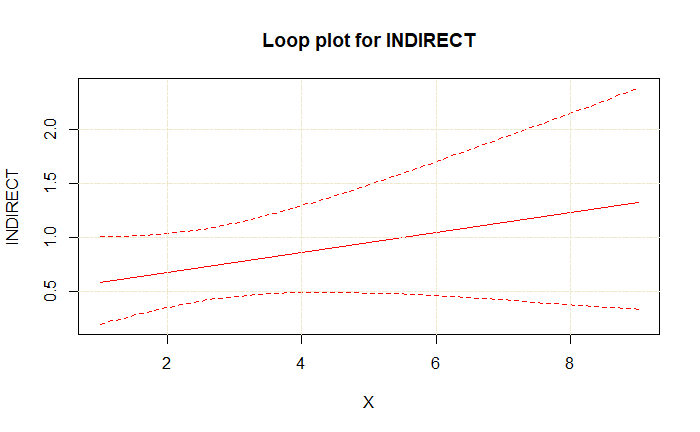

```r
mplus.plot.loop("ex2.29.gh5", 1)
```

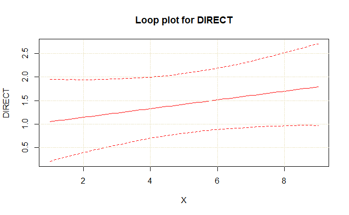

```r
mplus.plot.loop("ex2.29.gh5", 2)
```

**3. Extract results on R for each of the evaluation points by using functions available in** `mplus.R` (`mplus.get.loop.xvalues`, `mplus.get.loop.estimates`, `mplus.get.loop.lowerci`**, and** `mplus.get.loop.upperci`). **Provide the R code and output table for each of (a) indirect effects and (b) total effects.**

Mediation Effects:

```r
tibble(
  negexp = mplus.get.loop.xvalues("ex2.29.gh5"),
  ests = mplus.get.loop.estimates("ex2.29.gh5", 1),
  loci = mplus.get.loop.lowerci("ex2.29.gh5", 1),
  upci = mplus.get.loop.upperci("ex2.29.gh5", 1))
```

| negexp | ests | loci | upci |
| --- | --- | --- | --- |
| 1.000000 | 0.5805021 | 0.1917135 | 1.004786 |
| 1.100000 | 0.5897340 | 0.2093921 | 1.009104 |
| 1.200000 | 0.5989658 | 0.2279184 | 1.009277 |
| 1.300000 | 0.6081977 | 0.2426219 | 1.008291 |
| 1.400000 | 0.6174296 | 0.2589879 | 1.009498 |
| 1.500000 | 0.6266615 | 0.2747744 | 1.013991 |
| 1.600000 | 0.6358933 | 0.2912358 | 1.016717 |
| 1.700000 | 0.6451252 | 0.3063876 | 1.020771 |
| 1.800000 | 0.6543571 | 0.3215247 | 1.026675 |
| 1.900000 | 0.6635889 | 0.3363497 | 1.029872 |

[output cut: 71 more lines]

Direct Effects:

```r
tibble(
  negexp = mplus.get.loop.xvalues("ex2.29.gh5"),
  ests = mplus.get.loop.estimates("ex2.29.gh5", 2),
  loci = mplus.get.loop.lowerci("ex2.29.gh5", 2),
  upci = mplus.get.loop.upperci("ex2.29.gh5", 2))
```

| negexp | ests | loci | upci |
| --- | --- | --- | --- |
| 1.000000 | 1.051793 | 0.2075669 | 1.950009 |
| 1.100000 | 1.061025 | 0.2280459 | 1.947432 |
| 1.200000 | 1.070257 | 0.2509727 | 1.946866 |
| 1.300000 | 1.079489 | 0.2681727 | 1.946418 |
| 1.400000 | 1.088721 | 0.2880598 | 1.945877 |
| 1.500000 | 1.097952 | 0.3049089 | 1.942639 |
| 1.600000 | 1.107184 | 0.3236799 | 1.945046 |
| 1.700000 | 1.116416 | 0.3439966 | 1.943674 |
| 1.800000 | 1.125648 | 0.3606046 | 1.939878 |
| 1.900000 | 1.134880 | 0.3801372 | 1.938350 |

[output cut: 71 more lines]

## Part III

**By using the coping data in Part I, examine the mediation effect of efficacy `v2` -> resilience `v3` -> problem solving `v4`, whether it is moderated by stress `v1` if `v1` interacts with resilience `v3`. In other words, test the moderated mediation effect depicted in the following diagram.**

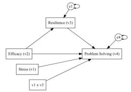

**Note that this analysis falls into the “Case 2” in the course slide set, where both mediation effect and direct effect would be moderated by the covariate (v1 in this case).**

**Conduct the analysis with Mplus by using `MplusAutomation` package. Specifications should include:**

- Use the `MOD` keyword under the `model indirect:` command line in the Mplus syntax.
- Compute the mediation effects for the range of (7, 50) with an increment of 0.1 for the moderator stress `v1`.
- Evaluate the mediation effects for an increment of 1 SD increase in the exposure variable efficacy `v2`. In other words, use $(x_1, x_0)=(37.48, 30.06)$.
- Use `bootstrap = 5000`.
- Request `PLOT: type = plot3;` to produce a graphical data file.

**1. Provide the R code for (a) generating external syntax file for Mplus by the combination of `sink()` and `cat()` functions, and (b) running the model by the `runModels()` function.**

```r
sink(file = "project2q3.inp")
cat('
data:     file = coping.dat;
variable: names = v1 v2 v3 v4;
          usev = v1 v2 v3 v4 v1v3int;
define:   v1v3int = v1*v3;
analysis: estimator = ml;
          bootstrap = 5000;
model:    v4 on v1 v2 v3 v1v3int;
          v3 on v2;
model indirect:
          v4 MOD v3 v1(7, 50, 0.1) v1v3int v2 (37.48, 30.06)
output:   cinterval (bootstrap);
plot:     type = plot3;
  ', fill=T)
sink()
```

```r
runModels("project2q3.inp")
```

```
Mplus VERSION 8.6
MUTHEN & MUTHEN
02/16/2024  11:30 PM

INPUT INSTRUCTIONS


  data:     file = coping.dat;
  variable: names = v1 v2 v3 v4;
            usev = v1 v2 v3 v4 v1v3int;
  define:   v1v3int = v1*v3;
  analysis: estimator = ml;
            bootstrap = 5000;
  model:    v4 on v1 v2 v3 v1v3int;
            v3 on v2;
  model indirect:
            v4 MOD v3 v1(7, 50, 0.1) v1v3int v2 (37.48, 30.06)
  output:   cinterval (bootstrap);
  plot:     type = plot3;




INPUT READING TERMINATED NORMALLY




SUMMARY OF ANALYSIS

Number of groups                                                 1
Number of observations                                         200

Number of dependent variables                                    2
Number of independent variables                                  3
Number of continuous latent variables                            0

Observed dependent variables

  Continuous
```

[output cut: 10505 more lines]

```
        Ending Time:  23:32:02
       Elapsed Time:  00:02:01



MUTHEN & MUTHEN
3463 Stoner Ave.
Los Angeles, CA  90066

Tel: (310) 391-9971
Fax: (310) 391-8971
Web: www.StatModel.com
Support: Support@StatModel.com

Copyright (c) 1998-2021 Muthen & Muthen
```

2. **Draw a plot to show the estimated moderated mediation effect and the 95% CI band using** `mplus.plot.moderation()` **function available in** `mplus.R`.**Provide the R code and plot. Comment (a) how the mediation effect changes based on the value of the moderator, and (b) approximately what range of the moderator values is associated with statistically significant mediation effect.**

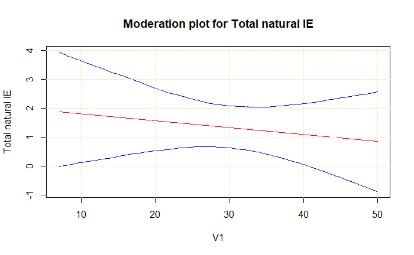

```r
mplus.plot.moderation("project2q3.gh5")
```

- (2-a). **The mediation effect is constantly positive in the range of the moderator values [7, 50]. As the mediation effect has an decreasing trend as the value of the moderator becomes larger, the mediation effect is in fact larger in positive value, when the moderator value is smaller. In other words, the mediation effect was larger for people who had lower in stress.**
- (2-b). **By evaluating the plot, the mediation effect was statistically significant for the range of approximately [8, 40] on stress (v1).**
3. **Extract estimated mediation effect and 95% CI for each of the evaluation points by using functions available in** `mplus.R` (`mplus.get.moderation.xvalues`, `mplus.get.moderation.estimates`, `mplus.get.moderation.lowerci`, **and** `mplus.get.moderation.upperci`). **Provide the R code and output table. Comment on what range of the moderator values is associated with statistically significant mediation effect.**

```r
tibble(
  stress = mplus.get.moderation.xvalues("project2q3.gh5"),
  ests = mplus.get.moderation.estimates("project2q3.gh5"),
  loci = mplus.get.moderation.lowerci("project2q3.gh5"),
  upci = mplus.get.moderation.upperci("project2q3.gh5"))
```

| stress | ests | loci | upci |
| --- | --- | --- | --- |
| 7.0 | 1.8785002 | -0.028681325 | 3.945081 |
| 7.1 | 1.8761232 | -0.024527181 | 3.933449 |
| 7.2 | 1.8737460 | -0.017185973 | 3.921817 |
| 7.3 | 1.8713689 | -0.009844767 | 3.910184 |
| 7.4 | 1.8689917 | -0.002503560 | 3.898552 |
| 7.5 | 1.8666147 | 0.004837647 | 3.886920 |
| 7.6 | 1.8642375 | 0.009733004 | 3.875288 |
| 7.7 | 1.8618604 | 0.011050783 | 3.863656 |
| 7.8 | 1.8594832 | 0.017976204 | 3.852024 |
| 7.9 | 1.8571061 | 0.021747412 | 3.840392 |

[output cut: 421 more lines]

The moderator stress (v1) is associated with a statistically significant mediation effect for values between 7.5 and 40.7, as the 95% confidence interval does not include 0 for those values.